# Movie Genre Data Analysis

## Introduction

This research explores patterns in the film industry by examining how genres, budgets, revenues, profits, popularity, and voting averages shape movie performance. The study is guided by key questions such as which genres dominate in production, deliver the highest financial returns, and capture the most audience approval, as well as how revenue and budget trends vary across different years. To deepen the analysis, several hypotheses are tested to investigate whether high ratings, popularity, or large budgets truly drive profit and revenue, and whether certain genres or production years offer consistent long-term efficiency. Together, these questions and hypotheses aim to highlight not only which films succeed, but also what factors make them sustainable investments in the movie market.

## Research Questions (Q):

1. Which genres are the most common (number of movies made)?
2. Which genres have high avg. budget and revenue?
3. Which genres have high avg. profit?
4. Which genres have high avg. popularity?
5. Which genres have highest number of movies with an voting avg. >=8?
6. Which production years saw the highest total revenue, and how does this align with budget trends?

## Research Hypotheses (H):

1. The best movies according to vote avg. return high profit and revenue.
2. The best movies according to popularity return high profit and revenue.
3. Highly budgeted movies return high revenue and profit.
4. Highly budgeted movies have a high popularity.
5. Profit per genre per year
6. Movies released in certain years achieve higher revenue/ROI than others
7. Genres with consistently high ROI are better long-term targets than high-budget genres

```python
import pandas as pd

movies = pd.read_csv('/Users/justiceoppongtuah/Library/CloudStorage/OneDrive-Personal/Pandas Project/imdb_movies.csv')
```

```python
movies.info()
```

```
<class 'pandas.core.frame.DataFrame'>
RangeIndex: 10866 entries, 0 to 10865
Data columns (total 21 columns):
 #   Column                Non-Null Count  Dtype
---  ------                --------------  -----
 0   id                    10866 non-null  int64
 1   imdb_id               10856 non-null  object
 2   popularity            10866 non-null  float64
 3   budget                10866 non-null  int64
 4   revenue               10866 non-null  int64
 5   original_title        10866 non-null  object
 6   cast                  10790 non-null  object
 7   homepage              2936 non-null   object
 8   director              10822 non-null  object
 9   tagline               8042 non-null   object
 10  keywords              9373 non-null   object
 11  overview              10862 non-null  object
 12  runtime               10866 non-null  int64
 13  genres                10843 non-null  object
 14  production_companies  9836 non-null   object
 15  release_date          10866 non-null  object
 16  vote_count            10866 non-null  int64
 17  vote_average          10866 non-null  float64
 18  release_year          10866 non-null  int64
 19  budget_adj            10866 non-null  float64
 20  revenue_adj           10866 non-null  float64
dtypes: float64(4), int64(6), object(11)
memory usage: 1.7+ MB
```

```python
pd.set_option('display.max.rows', 11000)
pd.set_option('display.max.columns', 22)
```

```python
movies.head()
```

|  | id | imdb_id | popularity | budget | revenue | original_title | cast | homepage | director | tagline | keywords | overview | runtime | genres | production_companies | release_date | vote_count | vote_average | release_year | budget_adj | revenue_adj |
| --- | --- | --- | --- | --- | --- | --- | --- | --- | --- | --- | --- | --- | --- | --- | --- | --- | --- | --- | --- | --- | --- |
| 0 | 135397 | tt0369610 | 32.985763 | 150000000 | 1513528810 | Jurassic World | Chris Pratt\|Bryce Dallas Howard\|Irrfan Khan\|Vi... | http://www.jurassicworld.com/ | Colin Trevorrow | The park is open. | monster\|dna\|tyrannosaurus rex\|velociraptor\|island | Twenty-two years after the events of Jurassic ... | 124 | Action\|Adventure\|Science Fiction\|Thriller | Universal Studios\|Amblin Entertainment\|Legenda... | 6/9/15 | 5562 | 6.500000 | 2015 | 137999939.280026 | 1392445892.523800 |
| 1 | 76341 | tt1392190 | 28.419936 | 150000000 | 378436354 | Mad Max: Fury Road | Tom Hardy\|Charlize Theron\|Hugh Keays-Byrne\|Nic... | http://www.madmaxmovie.com/ | George Miller | What a Lovely Day. | future\|chase\|post-apocalyptic\|dystopia\|australia | An apocalyptic story set in the furthest reach... | 120 | Action\|Adventure\|Science Fiction\|Thriller | Village Roadshow Pictures\|Kennedy Miller Produ... | 5/13/15 | 6185 | 7.100000 | 2015 | 137999939.280026 | 348161292.489031 |
| 2 | 262500 | tt2908446 | 13.112507 | 110000000 | 295238201 | Insurgent | Shailene Woodley\|Theo James\|Kate Winslet\|Ansel... | http://www.thedivergentseries.movie/#insurgent | Robert Schwentke | One Choice Can Destroy You | based on novel\|revolution\|dystopia\|sequel\|dyst... | Beatrice Prior must confront her inner demons ... | 119 | Adventure\|Science Fiction\|Thriller | Summit Entertainment\|Mandeville Films\|Red Wago... | 3/18/15 | 2480 | 6.300000 | 2015 | 101199955.472019 | 271619025.407628 |
| 3 | 140607 | tt2488496 | 11.173104 | 200000000 | 2068178225 | Star Wars: The Force Awakens | Harrison Ford\|Mark Hamill\|Carrie Fisher\|Adam D... | http://www.starwars.com/films/star-wars-episod... | J.J. Abrams | Every generation has a story. | android\|spaceship\|jedi\|space opera\|3d | Thirty years after defeating the Galactic Empi... | 136 | Action\|Adventure\|Science Fiction\|Fantasy | Lucasfilm\|Truenorth Productions\|Bad Robot | 12/15/15 | 5292 | 7.500000 | 2015 | 183999919.040035 | 1902723129.801820 |
| 4 | 168259 | tt2820852 | 9.335014 | 190000000 | 1506249360 | Furious 7 | Vin Diesel\|Paul Walker\|Jason Statham\|Michelle ... | http://www.furious7.com/ | James Wan | Vengeance Hits Home | car race\|speed\|revenge\|suspense\|car | Deckard Shaw seeks revenge against Dominic Tor... | 137 | Action\|Crime\|Thriller | Universal Pictures\|Original Film\|Media Rights ... | 4/1/15 | 2947 | 7.300000 | 2015 | 174799923.088033 | 1385748801.470520 |

## Data Cleaning

### 1. Checking for duplicates:

```python
movies[movies.duplicated()]
```

|  | id | imdb_id | popularity | budget | revenue | original_title | cast | homepage | director | tagline | keywords | overview | runtime | genres | production_companies | release_date | vote_count | vote_average | release_year | budget_adj | revenue_adj |
| --- | --- | --- | --- | --- | --- | --- | --- | --- | --- | --- | --- | --- | --- | --- | --- | --- | --- | --- | --- | --- | --- |
| 2090 | 42194 | tt0411951 | 0.596430 | 30000000 | 967000 | TEKKEN | Jon Foo\|Kelly Overton\|Cary-Hiroyuki Tagawa\|Ian... | NaN | Dwight H. Little | Survival is no game | martial arts\|dystopia\|based on video game\|mart... | In the year of 2039, after World Wars destroy ... | 92 | Crime\|Drama\|Action\|Thriller\|Science Fiction | Namco\|Light Song Films | 3/20/10 | 110 | 5.000000 | 2010 | 30000000.000000 | 967000.000000 |

### Deleting duplicates:

```python
movies.drop_duplicates(inplace = True)
```

```python
movies[movies.duplicated()]
```

|  | id | imdb_id | popularity | budget | revenue | original_title | cast | homepage | director | tagline | keywords | overview | runtime | genres | production_companies | release_date | vote_count | vote_average | release_year | budget_adj | revenue_adj |
| --- | --- | --- | --- | --- | --- | --- | --- | --- | --- | --- | --- | --- | --- | --- | --- | --- | --- | --- | --- | --- | --- |

### 2. Deleting null data

a. from the info 'genres' has (10866 - 10843) rows being null

```python
movies.dropna(subset = ['genres'], inplace = True)
```

```python
movies.info()
```

```
<class 'pandas.core.frame.DataFrame'>
Index: 10842 entries, 0 to 10865
Data columns (total 21 columns):
 #   Column                Non-Null Count  Dtype
---  ------                --------------  -----
 0   id                    10842 non-null  int64
 1   imdb_id               10834 non-null  object
 2   popularity            10842 non-null  float64
 3   budget                10842 non-null  int64
 4   revenue               10842 non-null  int64
 5   original_title        10842 non-null  object
 6   cast                  10767 non-null  object
 7   homepage              2931 non-null   object
 8   director              10800 non-null  object
 9   tagline               8036 non-null   object
 10  keywords              9367 non-null   object
 11  overview              10839 non-null  object
 12  runtime               10842 non-null  int64
 13  genres                10842 non-null  object
 14  production_companies  9826 non-null   object
 15  release_date          10842 non-null  object
 16  vote_count            10842 non-null  int64
 17  vote_average          10842 non-null  float64
 18  release_year          10842 non-null  int64
 19  budget_adj            10842 non-null  float64
 20  revenue_adj           10842 non-null  float64
dtypes: float64(4), int64(6), object(11)
memory usage: 1.8+ MB
```

### Calculating and adding 'profit' field to the data

```python
movies['profit'] = movies['revenue'] - movies['budget']
```

### Extracting Fields to Work with:

```python
movies_genre = movies[['popularity', 'budget', 'revenue', 'original_title', 'runtime', 'genres', 'release_year', 'vote_count', 'vote_average', 'profit']]
movies_genre.head()
```

```python
from pandas import Series, DataFrame
```

### Expanding the data by 'genres' per row

This is to make it more useful for our use cases:

```python
movies_genre = (movies_genre.assign(genre=movies_genre['genres'].str.split('|')).explode('genre').drop(columns='genres'))
```

```python
movies_genre
```

|  | popularity | budget | revenue | original_title | runtime | release_year | vote_count | vote_average | profit | genre |
| --- | --- | --- | --- | --- | --- | --- | --- | --- | --- | --- |
| 0 | 32.985763 | 150000000 | 1513528810 | Jurassic World | 124 | 2015 | 5562 | 6.500000 | 1363528810 | Action |
| 0 | 32.985763 | 150000000 | 1513528810 | Jurassic World | 124 | 2015 | 5562 | 6.500000 | 1363528810 | Adventure |
| 0 | 32.985763 | 150000000 | 1513528810 | Jurassic World | 124 | 2015 | 5562 | 6.500000 | 1363528810 | Science Fiction |
| 0 | 32.985763 | 150000000 | 1513528810 | Jurassic World | 124 | 2015 | 5562 | 6.500000 | 1363528810 | Thriller |
| 1 | 28.419936 | 150000000 | 378436354 | Mad Max: Fury Road | 120 | 2015 | 6185 | 7.100000 | 228436354 | Action |
| ... | ... | ... | ... | ... | ... | ... | ... | ... | ... | ... |
| 10863 | 0.065141 | 0 | 0 | Beregis Avtomobilya | 94 | 1966 | 11 | 6.500000 | 0 | Mystery |
| 10863 | 0.065141 | 0 | 0 | Beregis Avtomobilya | 94 | 1966 | 11 | 6.500000 | 0 | Comedy |
| 10864 | 0.064317 | 0 | 0 | What's Up, Tiger Lily? | 80 | 1966 | 22 | 5.400000 | 0 | Action |
| 10864 | 0.064317 | 0 | 0 | What's Up, Tiger Lily? | 80 | 1966 | 22 | 5.400000 | 0 | Comedy |
| 10865 | 0.035919 | 19000 | 0 | Manos: The Hands of Fate | 74 | 1966 | 15 | 1.500000 | -19000 | Horror |

26955 rows × 10 columns

```python
movies_genre.head(10)
```

|  | popularity | budget | revenue | original_title | runtime | release_year | vote_count | vote_average | profit | genre |
| --- | --- | --- | --- | --- | --- | --- | --- | --- | --- | --- |
| 0 | 32.985763 | 150000000 | 1513528810 | Jurassic World | 124 | 2015 | 5562 | 6.500000 | 1363528810 | Action |
| 0 | 32.985763 | 150000000 | 1513528810 | Jurassic World | 124 | 2015 | 5562 | 6.500000 | 1363528810 | Adventure |
| 0 | 32.985763 | 150000000 | 1513528810 | Jurassic World | 124 | 2015 | 5562 | 6.500000 | 1363528810 | Science Fiction |
| 0 | 32.985763 | 150000000 | 1513528810 | Jurassic World | 124 | 2015 | 5562 | 6.500000 | 1363528810 | Thriller |
| 1 | 28.419936 | 150000000 | 378436354 | Mad Max: Fury Road | 120 | 2015 | 6185 | 7.100000 | 228436354 | Action |
| 1 | 28.419936 | 150000000 | 378436354 | Mad Max: Fury Road | 120 | 2015 | 6185 | 7.100000 | 228436354 | Adventure |
| 1 | 28.419936 | 150000000 | 378436354 | Mad Max: Fury Road | 120 | 2015 | 6185 | 7.100000 | 228436354 | Science Fiction |
| 1 | 28.419936 | 150000000 | 378436354 | Mad Max: Fury Road | 120 | 2015 | 6185 | 7.100000 | 228436354 | Thriller |
| 2 | 13.112507 | 110000000 | 295238201 | Insurgent | 119 | 2015 | 2480 | 6.300000 | 185238201 | Adventure |
| 2 | 13.112507 | 110000000 | 295238201 | Insurgent | 119 | 2015 | 2480 | 6.300000 | 185238201 | Science Fiction |

## Research Questions (Q):

**1. Which genres are the most common (number of movies made)?**

```python
genres_count = pd.DataFrame(movies_genre.groupby('genre').original_title.nunique()).sort_values('original_title', ascending = True)
```

```python
genres_count
```

| genre | original_title |
| --- | --- |
| Western | 163 |
| TV Movie | 167 |
| Foreign | 188 |
| War | 269 |
| History | 331 |
| Music | 403 |
| Documentary | 520 |
| Animation | 697 |
| Mystery | 796 |
| Fantasy | 899 |
| Science Fiction | 1207 |
| Family | 1211 |
| Crime | 1337 |
| Adventure | 1442 |
| Horror | 1580 |
| Romance | 1686 |
| Action | 2339 |
| Thriller | 2841 |
| Comedy | 3750 |
| Drama | 4672 |

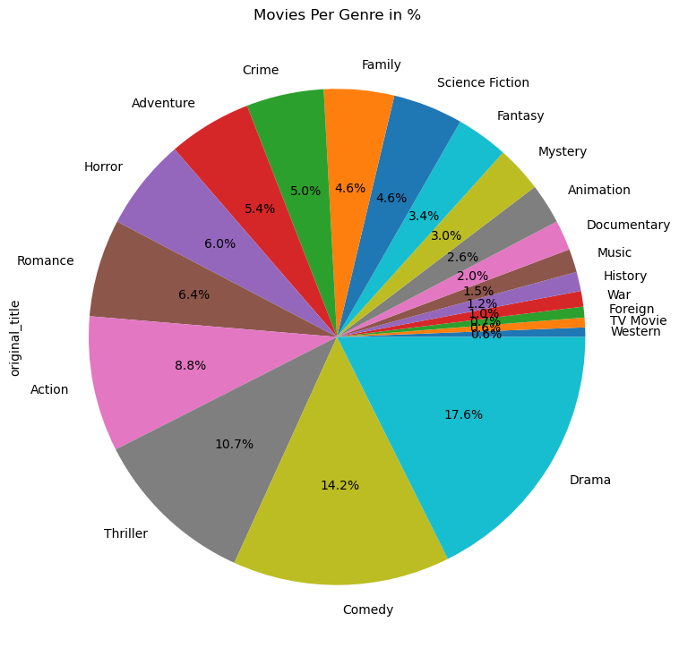

```python
genres_count['original_title'].plot.pie(title = 'Movies Per Genre in %', autopct = '%1.1f%%', figsize = (9,9))
```

**The analysis above shows that Drama, Comedy, and Thriller are the most common genres, with Drama leading at 4,672 movies. The pie chart highlights how these genres dominate film production compared to less common ones like Western, TV Movie, and Foreign.**

**2. Which genres have high avg. budget and revenue?**

```python
genres_avg = genres_count.groupby('genre').mean()
genres_avg
```

| genre | original_title |
| --- | --- |
| Action | 2339.000000 |
| Adventure | 1442.000000 |
| Animation | 697.000000 |
| Comedy | 3750.000000 |
| Crime | 1337.000000 |
| Documentary | 520.000000 |
| Drama | 4672.000000 |
| Family | 1211.000000 |
| Fantasy | 899.000000 |
| Foreign | 188.000000 |
| History | 331.000000 |
| Horror | 1580.000000 |
| Music | 403.000000 |
| Mystery | 796.000000 |
| Romance | 1686.000000 |
| Science Fiction | 1207.000000 |
| TV Movie | 167.000000 |
| Thriller | 2841.000000 |
| War | 269.000000 |
| Western | 163.000000 |

```python
genres_avg = movies_genre.groupby('genre').mean(numeric_only = True)
pd.options.display.float_format = '{:2f}'.format

genres_avg
```

| genre | popularity | budget | revenue | runtime | release_year | vote_count | vote_average | profit |
| --- | --- | --- | --- | --- | --- | --- | --- | --- |
| Action | 0.926274 | 27727820.331376 | 72794732.002517 | 104.917785 | 2000.056208 | 392.993708 | 5.787752 | 45066911.671141 |
| Adventure | 1.154259 | 37543694.530931 | 113137861.069341 | 106.173351 | 1999.388851 | 513.125085 | 5.940585 | 75594166.538409 |
| Animation | 0.852182 | 23159781.606581 | 75256062.223176 | 68.181688 | 2003.995708 | 303.000000 | 6.403147 | 52096280.616595 |
| Comedy | 0.592607 | 13297915.618244 | 37526242.072238 | 96.745057 | 2000.816240 | 176.436330 | 5.905167 | 24228326.453994 |
| Crime | 0.744930 | 17663801.124815 | 42368661.645495 | 106.917282 | 1999.491137 | 278.805022 | 6.124889 | 24704860.520679 |
| Documentary | 0.181432 | 577149.148077 | 2041106.994231 | 102.651923 | 2008.313462 | 35.105769 | 6.908462 | 1463957.846154 |
| Drama | 0.591495 | 11880717.773529 | 29232255.725840 | 110.478151 | 2000.929202 | 182.544538 | 6.165546 | 17351537.952311 |
| Family | 0.786668 | 23359337.420796 | 72433176.373680 | 89.603574 | 2000.774167 | 272.320877 | 5.997563 | 49073838.952884 |
| Fantasy | 0.992840 | 32612585.348253 | 96313657.081878 | 100.736900 | 2000.292576 | 420.741266 | 5.863537 | 63701071.733624 |
| Foreign | 0.191496 | 1451434.925532 | 1520459.835106 | 107.228723 | 2001.398936 | 16.627660 | 5.981383 | 69024.909574 |
| History | 0.575936 | 18594919.302395 | 32011793.215569 | 136.206587 | 1997.497006 | 183.772455 | 6.410479 | 13416873.913174 |
| Horror | 0.465357 | 6226529.210751 | 16822808.624313 | 94.424557 | 2001.117288 | 120.059866 | 5.337447 | 10596279.413561 |
| Music | 0.487321 | 9438627.549020 | 28571768.691176 | 105.137255 | 2000.196078 | 124.340686 | 6.480392 | 19133141.142157 |
| Mystery | 0.690012 | 16119270.062963 | 40217566.661728 | 105.928395 | 1999.850617 | 236.998765 | 5.946790 | 24098296.598765 |
| Romance | 0.592082 | 12531271.847547 | 35691972.327103 | 106.891355 | 2000.438668 | 166.070678 | 6.042874 | 23160700.479556 |
| Science Fiction | 1.001548 | 24972680.524003 | 70140558.034174 | 99.419854 | 1999.978845 | 437.096013 | 5.665582 | 45167877.510171 |
| TV Movie | 0.270896 | 267664.670659 | 251497.005988 | 91.982036 | 2004.634731 | 34.365269 | 5.788024 | -16167.664671 |
| Thriller | 0.741563 | 17207693.769178 | 41728417.543860 | 103.247678 | 2001.693498 | 255.484348 | 5.750671 | 24520723.774682 |
| War | 0.727683 | 20891886.103704 | 47605183.300000 | 127.625926 | 1996.096296 | 270.733333 | 6.297778 | 26713297.196296 |
| Western | 0.590615 | 18974107.975758 | 28568709.284848 | 117.575758 | 1986.915152 | 205.739394 | 6.083030 | 9594601.309091 |

```python
genres_avg.sort_values('budget', ascending = True, inplace = True)
```

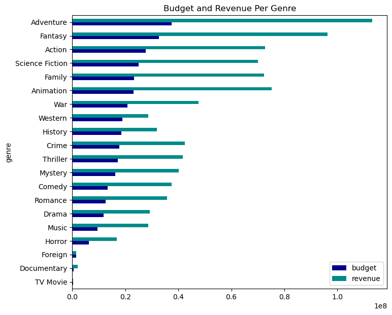

```python
genres_avg[['budget', 'revenue']].plot.barh(title = 'Budget and Revenue Per Genre', color = ('DarkBlue', 'DarkCyan'), figsize = (8,7))
```

**The analysis above reveals that Adventure, Fantasy, and Action genres stand out with the highest average budgets and revenues, reflecting their blockbuster nature. A horizontal bar chart was used to compare these values across genres, making it clear that large-scale productions typically dominate financial performance in the film industry.**

**3. Which genres have high avg. profit?**

```python
genres_avg
```

| genre | popularity | budget | revenue | runtime | release_year | vote_count | vote_average | profit |
| --- | --- | --- | --- | --- | --- | --- | --- | --- |
| Documentary | 0.181432 | 577149.148077 | 2041106.994231 | 102.651923 | 2008.313462 | 35.105769 | 6.908462 | 1463957.846154 |
| Foreign | 0.191496 | 1451434.925532 | 1520459.835106 | 107.228723 | 2001.398936 | 16.627660 | 5.981383 | 69024.909574 |
| TV Movie | 0.270896 | 267664.670659 | 251497.005988 | 91.982036 | 2004.634731 | 34.365269 | 5.788024 | -16167.664671 |
| Horror | 0.465357 | 6226529.210751 | 16822808.624313 | 94.424557 | 2001.117288 | 120.059866 | 5.337447 | 10596279.413561 |
| Music | 0.487321 | 9438627.549020 | 28571768.691176 | 105.137255 | 2000.196078 | 124.340686 | 6.480392 | 19133141.142157 |
| History | 0.575936 | 18594919.302395 | 32011793.215569 | 136.206587 | 1997.497006 | 183.772455 | 6.410479 | 13416873.913174 |
| Western | 0.590615 | 18974107.975758 | 28568709.284848 | 117.575758 | 1986.915152 | 205.739394 | 6.083030 | 9594601.309091 |
| Drama | 0.591495 | 11880717.773529 | 29232255.725840 | 110.478151 | 2000.929202 | 182.544538 | 6.165546 | 17351537.952311 |
| Romance | 0.592082 | 12531271.847547 | 35691972.327103 | 106.891355 | 2000.438668 | 166.070678 | 6.042874 | 23160700.479556 |
| Comedy | 0.592607 | 13297915.618244 | 37526242.072238 | 96.745057 | 2000.816240 | 176.436330 | 5.905167 | 24228326.453994 |
| Mystery | 0.690012 | 16119270.062963 | 40217566.661728 | 105.928395 | 1999.850617 | 236.998765 | 5.946790 | 24098296.598765 |
| War | 0.727683 | 20891886.103704 | 47605183.300000 | 127.625926 | 1996.096296 | 270.733333 | 6.297778 | 26713297.196296 |
| Thriller | 0.741563 | 17207693.769178 | 41728417.543860 | 103.247678 | 2001.693498 | 255.484348 | 5.750671 | 24520723.774682 |
| Crime | 0.744930 | 17663801.124815 | 42368661.645495 | 106.917282 | 1999.491137 | 278.805022 | 6.124889 | 24704860.520679 |
| Family | 0.786668 | 23359337.420796 | 72433176.373680 | 89.603574 | 2000.774167 | 272.320877 | 5.997563 | 49073838.952884 |
| Animation | 0.852182 | 23159781.606581 | 75256062.223176 | 68.181688 | 2003.995708 | 303.000000 | 6.403147 | 52096280.616595 |
| Action | 0.926274 | 27727820.331376 | 72794732.002517 | 104.917785 | 2000.056208 | 392.993708 | 5.787752 | 45066911.671141 |
| Fantasy | 0.992840 | 32612585.348253 | 96313657.081878 | 100.736900 | 2000.292576 | 420.741266 | 5.863537 | 63701071.733624 |
| Science Fiction | 1.001548 | 24972680.524003 | 70140558.034174 | 99.419854 | 1999.978845 | 437.096013 | 5.665582 | 45167877.510171 |
| Adventure | 1.154259 | 37543694.530931 | 113137861.069341 | 106.173351 | 1999.388851 | 513.125085 | 5.940585 | 75594166.538409 |

```python
genres_avg.sort_values('profit', ascending = True, inplace = True)
```

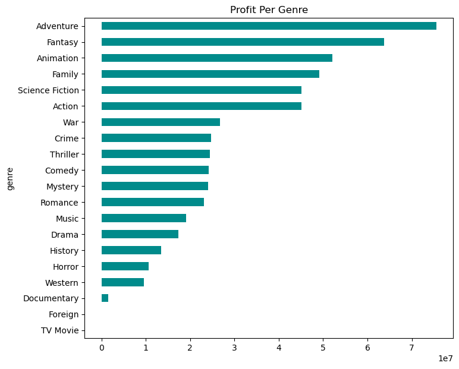

```python
genres_avg['profit'].plot.barh(title = 'Profit Per Genre', color = 'DarkCyan', figsize = (8,7))
```

**The analysis reveals that Adventure, Fantasy, Animation, and Family stand out as the most profitable genres, with Animation and Family even surpassing Science Fiction in average profit. A horizontal bar chart was used to visualize these results, showing blockbuster and family-oriented genres leading in financial returns.**

**4. Which genres have high avg. popularity?**

```python
genres_avg.sort_values('popularity', ascending = True, inplace = True)
```

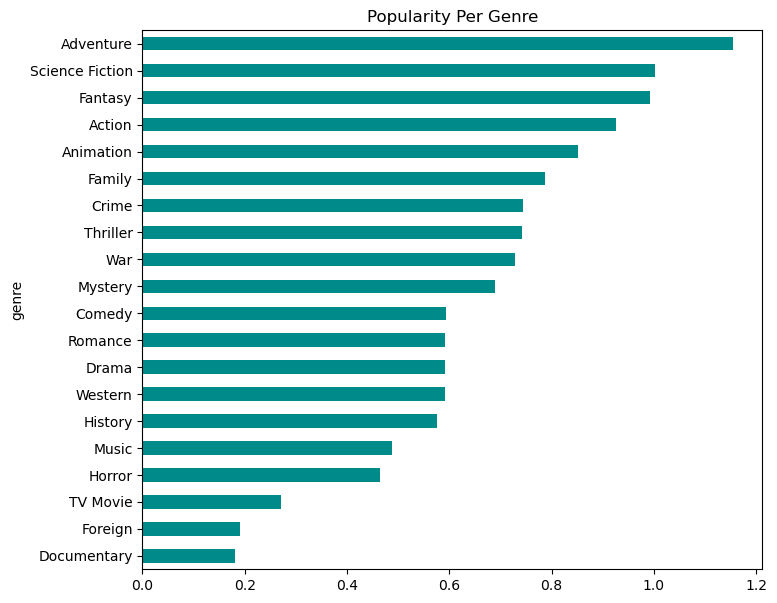

```python
genres_avg['popularity'].plot.barh(title = 'Popularity Per Genre', color = 'DarkCyan', figsize = (8,7))
```

**The analysis shows that Adventure, Fantasy and Science Fiction are the genres with the highest average popularity, indicating strong audience appeal. A horizontal bar chart was used to visualize the comparison, highlighting how these genres consistently attract the most attention.**

**5. Which genres have highest number of movies with an voting avg. >=8?**

```python
movies_genre.head(5)
```

|  | popularity | budget | revenue | original_title | runtime | release_year | vote_count | vote_average | profit | genre |
| --- | --- | --- | --- | --- | --- | --- | --- | --- | --- | --- |
| 0 | 32.985763 | 150000000 | 1513528810 | Jurassic World | 124 | 2015 | 5562 | 6.500000 | 1363528810 | Action |
| 0 | 32.985763 | 150000000 | 1513528810 | Jurassic World | 124 | 2015 | 5562 | 6.500000 | 1363528810 | Adventure |
| 0 | 32.985763 | 150000000 | 1513528810 | Jurassic World | 124 | 2015 | 5562 | 6.500000 | 1363528810 | Science Fiction |
| 0 | 32.985763 | 150000000 | 1513528810 | Jurassic World | 124 | 2015 | 5562 | 6.500000 | 1363528810 | Thriller |
| 1 | 28.419936 | 150000000 | 378436354 | Mad Max: Fury Road | 120 | 2015 | 6185 | 7.100000 | 228436354 | Action |

```python
vote_fifty = movies_genre[(movies_genre['vote_count'] >= 50) & (movies_genre['vote_average'] >= 8)]
vote_zero = movies_genre[movies_genre['vote_average'] >= 8]
```

```python
genres_vote = pd.DataFrame(vote_zero.groupby('genre').vote_average.nunique()).sort_values('vote_average', ascending = True)
genres_vote
```

| genre | vote_average |
| --- | --- |
| Family | 1 |
| Action | 2 |
| Mystery | 2 |
| History | 2 |
| Fantasy | 2 |
| Adventure | 2 |
| War | 2 |
| Horror | 3 |
| Romance | 3 |
| Science Fiction | 3 |
| Thriller | 4 |
| Animation | 4 |
| Crime | 4 |
| Comedy | 5 |
| Drama | 6 |
| Music | 8 |
| Documentary | 9 |

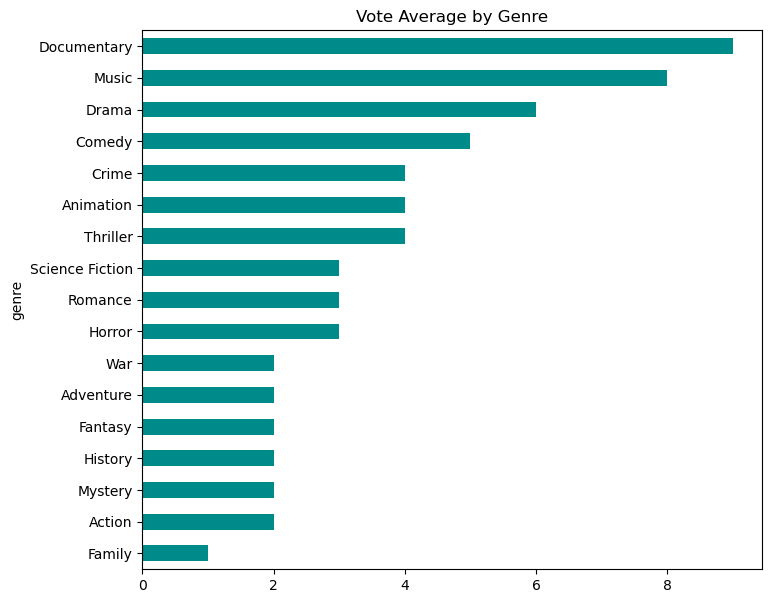

```python
genres_vote['vote_average'].plot.barh(title = 'Vote Average by Genre', color = 'DarkCyan', figsize = (8,7))
```

**6. Which production years saw the highest total revenue, and how does this align with budget trends?**

```python
import numpy as np
import matplotlib.pyplot as plt
```

```python
movies_genre
```

|  | popularity | budget | revenue | original_title | runtime | release_year | vote_count | vote_average | profit | genre |
| --- | --- | --- | --- | --- | --- | --- | --- | --- | --- | --- |
| 0 | 32.985763 | 150000000 | 1513528810 | Jurassic World | 124 | 2015 | 5562 | 6.500000 | 1363528810 | Action |
| 0 | 32.985763 | 150000000 | 1513528810 | Jurassic World | 124 | 2015 | 5562 | 6.500000 | 1363528810 | Adventure |
| 0 | 32.985763 | 150000000 | 1513528810 | Jurassic World | 124 | 2015 | 5562 | 6.500000 | 1363528810 | Science Fiction |
| 0 | 32.985763 | 150000000 | 1513528810 | Jurassic World | 124 | 2015 | 5562 | 6.500000 | 1363528810 | Thriller |
| 1 | 28.419936 | 150000000 | 378436354 | Mad Max: Fury Road | 120 | 2015 | 6185 | 7.100000 | 228436354 | Action |
| ... | ... | ... | ... | ... | ... | ... | ... | ... | ... | ... |
| 10863 | 0.065141 | 0 | 0 | Beregis Avtomobilya | 94 | 1966 | 11 | 6.500000 | 0 | Mystery |
| 10863 | 0.065141 | 0 | 0 | Beregis Avtomobilya | 94 | 1966 | 11 | 6.500000 | 0 | Comedy |
| 10864 | 0.064317 | 0 | 0 | What's Up, Tiger Lily? | 80 | 1966 | 22 | 5.400000 | 0 | Action |
| 10864 | 0.064317 | 0 | 0 | What's Up, Tiger Lily? | 80 | 1966 | 22 | 5.400000 | 0 | Comedy |
| 10865 | 0.035919 | 19000 | 0 | Manos: The Hands of Fate | 74 | 1966 | 15 | 1.500000 | -19000 | Horror |

26955 rows × 10 columns

```python
# Yearly totals
yearly_totals = (movies_genre.groupby('release_year')[['revenue', 'budget']].sum(min_count=1).dropna().sort_index())
```

```python
# Efficiency and ranks
yearly_totals['rev_to_budget_ratio'] = np.where(yearly_totals['budget'] > 0,yearly_totals['revenue'] / yearly_totals['budget'],np.nan)
```

```python
yearly_totals['revenue_rank'] = yearly_totals['revenue'].rank(ascending=False, method='min')
yearly_totals['budget_rank']  = yearly_totals['budget'].rank(ascending=False, method='min')
yearly_totals['rank_gap(rev-budget)'] = yearly_totals['revenue_rank'] - yearly_totals['budget_rank']
```

```python
# Top 10 years by total revenue
q6_top10 = yearly_totals.sort_values('revenue', ascending=False).head(10)
```

```python
display(yearly_totals.head(12))
display(q6_top10)
```

| release_year | revenue | budget | rev_to_budget_ratio | revenue_rank | budget_rank | rank_gap(rev-budget) |
| --- | --- | --- | --- | --- | --- | --- |
| 1960 | 417915000 | 64140844 | 6.515583 | 55.000000 | 56.000000 | -1.000000 |
| 1961 | 1201673874 | 117537000 | 10.223792 | 47.000000 | 54.000000 | -7.000000 |
| 1962 | 726409692 | 184194630 | 3.943707 | 53.000000 | 48.000000 | 5.000000 |
| 1963 | 552004390 | 237328000 | 2.325913 | 54.000000 | 45.000000 | 9.000000 |
| 1964 | 1178849290 | 134471644 | 8.766527 | 49.000000 | 52.000000 | -3.000000 |
| 1965 | 1525459848 | 212590345 | 7.175584 | 46.000000 | 46.000000 | 0.000000 |
| 1966 | 195736689 | 136164000 | 1.437507 | 56.000000 | 51.000000 | 5.000000 |
| 1967 | 2177966116 | 324282200 | 6.716268 | 42.000000 | 42.000000 | 0.000000 |
| 1968 | 817108595 | 238439000 | 3.426908 | 51.000000 | 44.000000 | 7.000000 |
| 1969 | 743971370 | 132203174 | 5.627485 | 52.000000 | 53.000000 | -1.000000 |
| 1970 | 1692997298 | 480535838 | 3.523145 | 45.000000 | 40.000000 | 5.000000 |
| 1971 | 1200690537 | 253348000 | 4.739294 | 48.000000 | 43.000000 | 5.000000 |

| release_year | revenue | budget | rev_to_budget_ratio | revenue_rank | budget_rank | rank_gap(rev-budget) |
| --- | --- | --- | --- | --- | --- | --- |
| 2015 | 82160071197 | 23020835159 | 3.568944 | 1.000000 | 8.000000 | -7.000000 |
| 2014 | 72059584262 | 23255945482 | 3.098545 | 2.000000 | 7.000000 | -5.000000 |
| 2012 | 72019644724 | 24044807311 | 2.995227 | 3.000000 | 5.000000 | -2.000000 |
| 2009 | 71844890702 | 26207420963 | 2.741395 | 4.000000 | 4.000000 | 0.000000 |
| 2013 | 70798442190 | 26406690003 | 2.681080 | 5.000000 | 3.000000 | 2.000000 |
| 2011 | 70142112650 | 26566819277 | 2.640215 | 6.000000 | 2.000000 | 4.000000 |
| 2010 | 65304621240 | 28482377815 | 2.292808 | 7.000000 | 1.000000 | 6.000000 |
| 2007 | 60426073803 | 23263499212 | 2.597463 | 8.000000 | 6.000000 | 2.000000 |
| 2008 | 54764768294 | 22167781392 | 2.470467 | 9.000000 | 9.000000 | 0.000000 |
| 2004 | 50004105495 | 21297896216 | 2.347842 | 10.000000 | 12.000000 | -2.000000 |

```python
# Correlation of yearly totals (how tightly budgets track revenue)
q6_spearman = yearly_totals[['revenue','budget']].corr(method='spearman').iloc[0,1]
print(f"[Q6] Spearman(revenue vs budget) across years = {q6_spearman:.3f}")
```

```
[Q6] Spearman(revenue vs budget) across years = 0.975
```

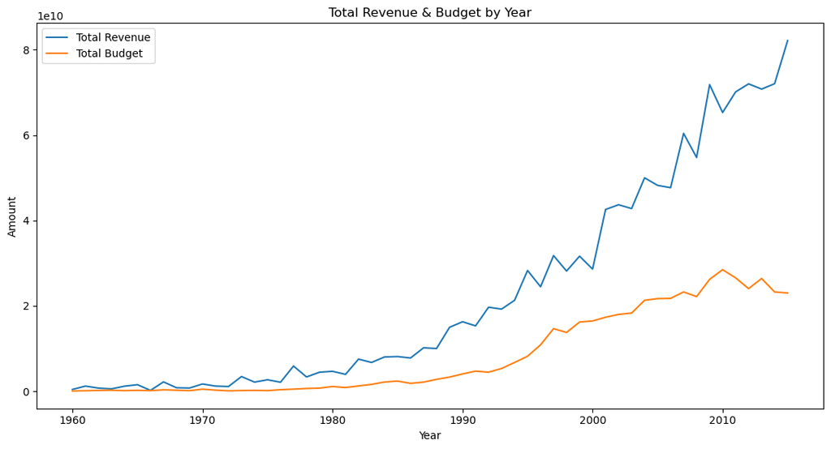

```python
# Plot: revenue vs budget over time
plt.figure(figsize=(11,6))
plt.plot(yearly_totals.index, yearly_totals['revenue'], label='Total Revenue')
plt.plot(yearly_totals.index, yearly_totals['budget'],  label='Total Budget')
plt.title('Total Revenue & Budget by Year')
plt.xlabel('Year'); plt.ylabel('Amount'); plt.legend(); plt.tight_layout(); plt.show()
```

**Q7) Which genres deliver the highest average ROI, and is high ROI consistent over time?**

ROI (Return on Investment) • Definition: A percentage that measures the efficiency of an investment relative to its cost.

```
•	Formula:
ROI = [{Profit (or Gain) from Investment} \ {Cost of Investment}]  * 100%

•	Type: Measured in percentage (%).

•	Purpose: Shows how effectively your investment generates returns — it answers “Was the investment worth it?”
```

```python
import matplotlib.pyplot as plt
import seaborn as sns
```

```python
# ROI at movie level (guard against division by zero)
movies_genre['profit'] = movies_genre['revenue'] - movies_genre['budget']
movies_genre['roi'] = np.where(movies_genre['budget'] > 0, movies_genre['profit'] / movies_genre['budget'], np.nan)
movies_genre.head()
```

|  | popularity | budget | revenue | original_title | runtime | release_year | vote_count | vote_average | profit | genre | roi |
| --- | --- | --- | --- | --- | --- | --- | --- | --- | --- | --- | --- |
| 0 | 32.985763 | 150000000 | 1513528810 | Jurassic World | 124 | 2015 | 5562 | 6.500000 | 1363528810 | Action | 9.090192 |
| 0 | 32.985763 | 150000000 | 1513528810 | Jurassic World | 124 | 2015 | 5562 | 6.500000 | 1363528810 | Adventure | 9.090192 |
| 0 | 32.985763 | 150000000 | 1513528810 | Jurassic World | 124 | 2015 | 5562 | 6.500000 | 1363528810 | Science Fiction | 9.090192 |
| 0 | 32.985763 | 150000000 | 1513528810 | Jurassic World | 124 | 2015 | 5562 | 6.500000 | 1363528810 | Thriller | 9.090192 |
| 1 | 28.419936 | 150000000 | 378436354 | Mad Max: Fury Road | 120 | 2015 | 6185 | 7.100000 | 228436354 | Action | 1.522909 |

```python
# Mean ROI per (genre, year)
roi_by_year = (
    movies_genre
    .dropna(subset=['release_year', 'roi'])
    .groupby(['genre', 'release_year'], as_index=False)['roi'].mean()
    .rename(columns={'release_year': 'year', 'roi': 'mean_roi_year'})
)
roi_by_year.head(15)
```

|  | genre | year | mean_roi_year |
| --- | --- | --- | --- |
| 0 | Action | 1960 | 2.726250 |
| 1 | Action | 1961 | 0.844444 |
| 2 | Action | 1962 | 18.171717 |
| 3 | Action | 1963 | 9.715914 |
| 4 | Action | 1964 | 34.685714 |
| 5 | Action | 1965 | 2.030697 |
| 6 | Action | 1966 | -0.014614 |
| 7 | Action | 1967 | 4.678831 |
| 8 | Action | 1968 | 4.209170 |
| 9 | Action | 1969 | 1.927660 |
| 10 | Action | 1970 | 1.375660 |
| 11 | Action | 1971 | 14.932931 |
| 12 | Action | 1972 | 12.283831 |
| 13 | Action | 1973 | 21.699363 |
| 14 | Action | 1974 | 6.609024 |

```python
# Consistency by genre: overall mean ROI, volatility across years, years observed
roi_consistency = (
    roi_by_year
    .groupby('genre', as_index=False)
    .agg(
        mean_roi=('mean_roi_year', 'mean'),
        roi_volatility=('mean_roi_year', 'std'),
        years_observed=('year', 'nunique')
    )
    .fillna({'roi_volatility': 0})
    .sort_values(['mean_roi', 'years_observed'], ascending=[False, False])
)

display(roi_consistency.head(20))
```

|  | genre | mean_roi | roi_volatility | years_observed |
| --- | --- | --- | --- | --- |
| 7 | Family | 5097.366486 | 36013.022664 | 50 |
| 14 | Romance | 1834.896107 | 13610.464854 | 56 |
| 1 | Adventure | 1659.294028 | 12374.474298 | 56 |
| 0 | Action | 1217.297322 | 9074.426205 | 56 |
| 6 | Drama | 822.291712 | 5678.375641 | 56 |
| 17 | Thriller | 77.977464 | 527.720212 | 55 |
| 3 | Comedy | 56.189440 | 329.346892 | 56 |
| 11 | Horror | 23.207555 | 79.766938 | 56 |
| 13 | Mystery | 22.797339 | 104.184279 | 51 |
| 5 | Documentary | 8.312802 | 24.843905 | 22 |
| 15 | Science Fiction | 4.964676 | 16.941324 | 53 |
| 12 | Music | 4.784395 | 8.749801 | 45 |
| 8 | Fantasy | 4.497297 | 18.673400 | 47 |
| 2 | Animation | 4.263699 | 9.198865 | 43 |
| 4 | Crime | 3.578558 | 5.809079 | 55 |
| 19 | Western | 1.896628 | 4.866633 | 39 |
| 18 | War | 1.868804 | 2.589981 | 48 |
| 10 | History | 1.344613 | 2.230760 | 48 |
| 16 | TV Movie | 0.200000 | 3.174902 | 7 |
| 9 | Foreign | -0.667293 | 0.621465 | 17 |

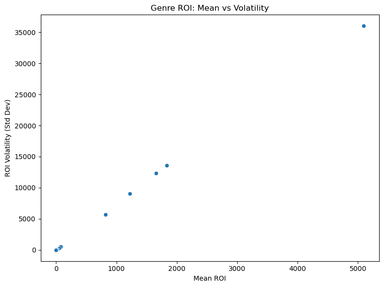

```python
# Visual: mean ROI vs volatility
plt.figure(figsize=(8,6))
sns.scatterplot(data=roi_consistency, x='mean_roi', y='roi_volatility')
plt.title('Genre ROI: Mean vs Volatility'); plt.xlabel('Mean ROI'); plt.ylabel('ROI Volatility (Std Dev)')
plt.tight_layout();
plt.show()
```

**The analysis shows that Family, Romance, and Adventure deliver the highest average ROI, although they also exhibit very high volatility across years. Genres such as Thriller, Comedy, and Horror offer more moderate but relatively stable returns. A scatter plot of mean ROI versus volatility was used to highlight the trade-off between profitability and consistency, helping to identify which genres balance high returns with lower risk.**

## Research Hypotheses (H):

**1. The best movies according to vote avg. return high profit and revenue.**

```python
movies_genre.head()
```

|  | popularity | budget | revenue | original_title | runtime | release_year | vote_count | vote_average | profit | genre | roi |
| --- | --- | --- | --- | --- | --- | --- | --- | --- | --- | --- | --- |
| 0 | 32.985763 | 150000000 | 1513528810 | Jurassic World | 124 | 2015 | 5562 | 6.500000 | 1363528810 | Action | 9.090192 |
| 0 | 32.985763 | 150000000 | 1513528810 | Jurassic World | 124 | 2015 | 5562 | 6.500000 | 1363528810 | Adventure | 9.090192 |
| 0 | 32.985763 | 150000000 | 1513528810 | Jurassic World | 124 | 2015 | 5562 | 6.500000 | 1363528810 | Science Fiction | 9.090192 |
| 0 | 32.985763 | 150000000 | 1513528810 | Jurassic World | 124 | 2015 | 5562 | 6.500000 | 1363528810 | Thriller | 9.090192 |
| 1 | 28.419936 | 150000000 | 378436354 | Mad Max: Fury Road | 120 | 2015 | 6185 | 7.100000 | 228436354 | Action | 1.522909 |

```python
movies_counted = movies_genre[movies_genre['vote_count'] >= 50]
movies_counted.corr(method='spearman', numeric_only=True)
```

|  | popularity | budget | revenue | runtime | release_year | vote_count | vote_average | profit | roi |
| --- | --- | --- | --- | --- | --- | --- | --- | --- | --- |
| popularity | 1.000000 | 0.496554 | 0.606165 | 0.231128 | 0.091893 | 0.776718 | 0.213364 | 0.516448 | 0.412798 |
| budget | 0.496554 | 1.000000 | 0.723696 | 0.355018 | 0.024279 | 0.573096 | -0.036132 | 0.343588 | 0.016027 |
| revenue | 0.606165 | 0.723696 | 1.000000 | 0.346976 | -0.075445 | 0.699428 | 0.126505 | 0.841594 | 0.713213 |
| runtime | 0.231128 | 0.355018 | 0.346976 | 1.000000 | -0.136733 | 0.269755 | 0.260482 | 0.223173 | 0.101995 |
| release_year | 0.091893 | 0.024279 | -0.075445 | -0.136733 | 1.000000 | 0.176190 | -0.134809 | -0.075017 | -0.146544 |
| vote_count | 0.776718 | 0.573096 | 0.699428 | 0.269755 | 0.176190 | 1.000000 | 0.307466 | 0.598132 | 0.490226 |
| vote_average | 0.213364 | -0.036132 | 0.126505 | 0.260482 | -0.134809 | 0.307466 | 1.000000 | 0.217354 | 0.298911 |
| profit | 0.516448 | 0.343588 | 0.841594 | 0.223173 | -0.075017 | 0.598132 | 0.217354 | 1.000000 | 0.837730 |
| roi | 0.412798 | 0.016027 | 0.713213 | 0.101995 | -0.146544 | 0.490226 | 0.298911 | 0.837730 | 1.000000 |

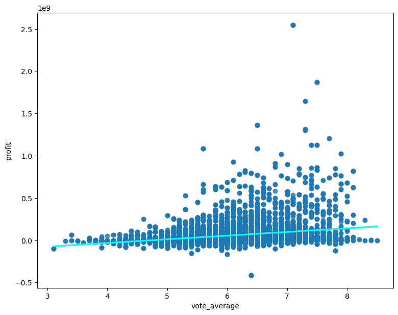

```python
import seaborn as sns
import matplotlib.pyplot as plt

plt.figure(figsize=(9,7))
sns.regplot(x = 'vote_average', y = 'profit', data = movies_counted, line_kws = {'color':'cyan'})
```

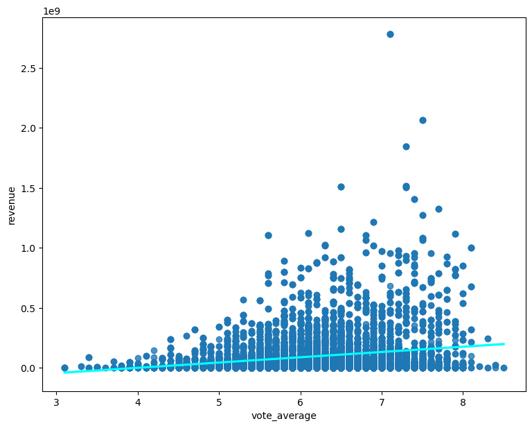

```python
plt.figure(figsize=(9,7))

sns.regplot(x = 'vote_average', y = 'revenue', data = movies_counted, line_kws = {'color':'cyan'})
```

****The correlation analysis shows a positive but relatively weak relationship between vote average and both profit and revenue. This suggests that while highly rated movies can generate strong financial returns, ratings alone are not the dominant driver of profit and revenue. A regression plot was used to visualize this relationship, showing the general upward trend but also the wide spread of data points.****

**2. The best movies according to popularity return high profit and revenue.**

```python
movies_counted.corr(method='spearman', numeric_only=True)
```

|  | popularity | budget | revenue | runtime | release_year | vote_count | vote_average | profit | roi |
| --- | --- | --- | --- | --- | --- | --- | --- | --- | --- |
| popularity | 1.000000 | 0.496554 | 0.606165 | 0.231128 | 0.091893 | 0.776718 | 0.213364 | 0.516448 | 0.412798 |
| budget | 0.496554 | 1.000000 | 0.723696 | 0.355018 | 0.024279 | 0.573096 | -0.036132 | 0.343588 | 0.016027 |
| revenue | 0.606165 | 0.723696 | 1.000000 | 0.346976 | -0.075445 | 0.699428 | 0.126505 | 0.841594 | 0.713213 |
| runtime | 0.231128 | 0.355018 | 0.346976 | 1.000000 | -0.136733 | 0.269755 | 0.260482 | 0.223173 | 0.101995 |
| release_year | 0.091893 | 0.024279 | -0.075445 | -0.136733 | 1.000000 | 0.176190 | -0.134809 | -0.075017 | -0.146544 |
| vote_count | 0.776718 | 0.573096 | 0.699428 | 0.269755 | 0.176190 | 1.000000 | 0.307466 | 0.598132 | 0.490226 |
| vote_average | 0.213364 | -0.036132 | 0.126505 | 0.260482 | -0.134809 | 0.307466 | 1.000000 | 0.217354 | 0.298911 |
| profit | 0.516448 | 0.343588 | 0.841594 | 0.223173 | -0.075017 | 0.598132 | 0.217354 | 1.000000 | 0.837730 |
| roi | 0.412798 | 0.016027 | 0.713213 | 0.101995 | -0.146544 | 0.490226 | 0.298911 | 0.837730 | 1.000000 |

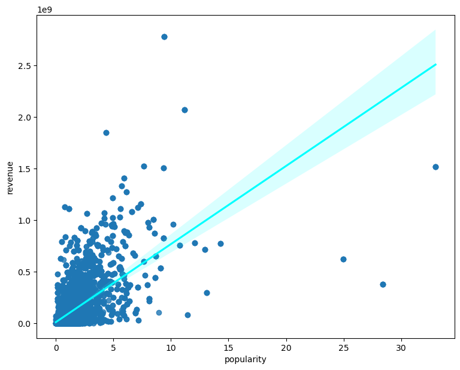

```python
import matplotlib.pyplot as plt

plt.figure(figsize = (9,7))
sns.regplot(x = 'popularity', y = 'revenue', data = movies_counted, line_kws = {'color':'cyan'})
plt.show()
```

**The correlation results show that popularity has a strong positive relationship with both revenue (0.61) and profit (0.52). This means that highly popular movies generally achieve higher commercial success, confirming the hypothesis. A regression plot was used to illustrate this trend, with a clear upward slope demonstrating how popularity drives financial performance.**

**3. Highly budgeted movies return high profit.**

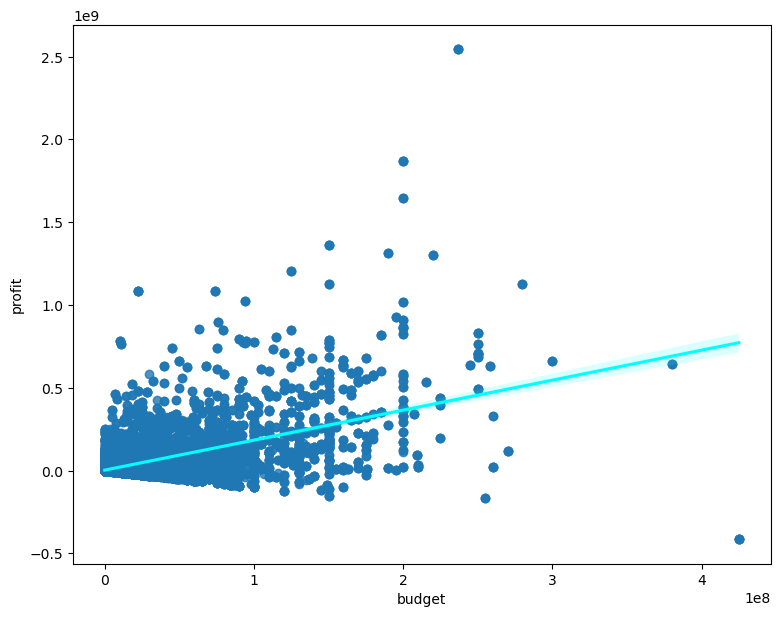

```python
plt.figure(figsize = (9,7))
sns.regplot(x = 'budget', y = 'profit', data = movies_counted, line_kws = {'color':'cyan'})
plt.show()
```

**The analysis shows a moderate positive relationship between budget and profit, indicating that higher-budget movies often achieve greater profits. However, the wide spread of data points in the regression plot highlights that large budgets do not always guarantee high returns.**

**4. Highly budgeted movies have a high popularity.**

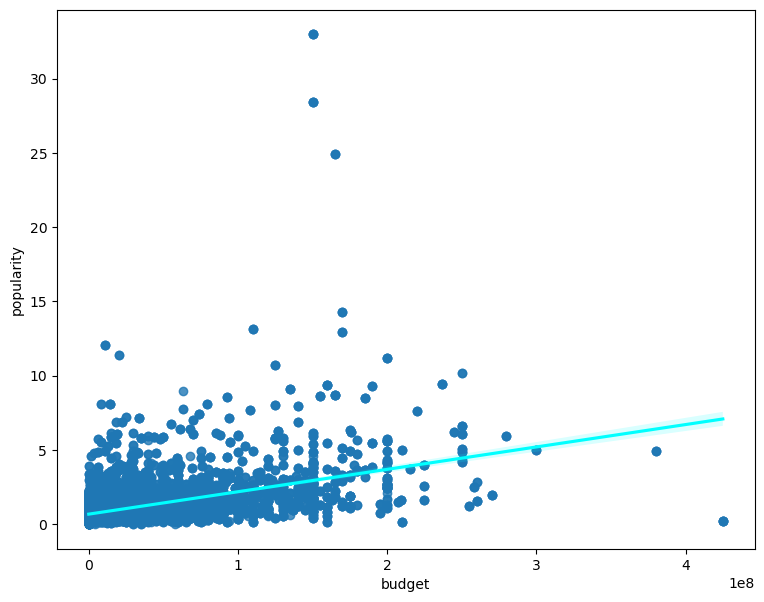

```python
plt.figure(figsize = (9,7))
sns.regplot(x = 'budget', y = 'popularity', data = movies_counted, line_kws = {'color':'cyan'})
plt.show()
```

### 5. Profit per Genre per Year

```python
movies_genre.head()
```

|  | popularity | budget | revenue | original_title | runtime | release_year | vote_count | vote_average | profit | genre | roi |
| --- | --- | --- | --- | --- | --- | --- | --- | --- | --- | --- | --- |
| 0 | 32.985763 | 150000000 | 1513528810 | Jurassic World | 124 | 2015 | 5562 | 6.500000 | 1363528810 | Action | 9.090192 |
| 0 | 32.985763 | 150000000 | 1513528810 | Jurassic World | 124 | 2015 | 5562 | 6.500000 | 1363528810 | Adventure | 9.090192 |
| 0 | 32.985763 | 150000000 | 1513528810 | Jurassic World | 124 | 2015 | 5562 | 6.500000 | 1363528810 | Science Fiction | 9.090192 |
| 0 | 32.985763 | 150000000 | 1513528810 | Jurassic World | 124 | 2015 | 5562 | 6.500000 | 1363528810 | Thriller | 9.090192 |
| 1 | 28.419936 | 150000000 | 378436354 | Mad Max: Fury Road | 120 | 2015 | 6185 | 7.100000 | 228436354 | Action | 1.522909 |

```python
time_genre = pd.DataFrame(movies_genre.groupby(['release_year', 'genre'])['profit'].mean())
time_genre.head(10)
```

| release_year | genre | profit |
| --- | --- | --- |
| 1960 | Action | 6363125.000000 |
|  | Adventure | 431000.000000 |
|  | Comedy | 5258750.000000 |
|  | Crime | 0.000000 |
|  | Drama | 8245619.384615 |
|  | Family | 3333333.333333 |
|  | Fantasy | -375000.000000 |
|  | Foreign | 0.000000 |
|  | History | 9600000.000000 |
|  | Horror | 4389007.428571 |

```python
pivot_genre = pd.pivot_table(time_genre, values = 'profit', index = ['genre'], columns = ['release_year'])
pivot_genre
```

| release_year genre | 1960 | 1961 | 1962 | 1963 | 1964 | 1965 | 1966 | 1967 | 1968 | 1969 | 1970 | ... | 2005 | 2006 | 2007 | 2008 | 2009 | 2010 | 2011 | 2012 | 2013 | 2014 | 2015 |
| --- | --- | --- | --- | --- | --- | --- | --- | --- | --- | --- | --- | --- | --- | --- | --- | --- | --- | --- | --- | --- | --- | --- | --- |
| Action | 6363125.000000 | 2457142.857143 | 10437500.000000 | 14999691.250000 | 24280000.000000 | 16104504.777778 | 324785.714286 | 21732786.428571 | 8868478.833333 | 5861449.300000 | 7735913.454545 | ... | 32379154.185714 | 38048623.212500 | 45977444.052632 | 47642764.404040 | 57555510.740741 | 34571030.355140 | 51968078.252174 | 71910257.424242 | 47431725.628099 | 69943650.015504 | 90399046.747664 |
| Adventure | 431000.000000 | 39130002.333333 | 21214285.714286 | 9428395.000000 | 24123400.000000 | 25124276.333333 | 791563.636364 | 49281873.857143 | 15122159.400000 | 16651809.400000 | 11406377.666667 | ... | 70756754.320755 | 64895200.090909 | 83916731.083333 | 55016526.809524 | 113364919.736111 | 98125646.677966 | 113343224.564516 | 162549574.300000 | 100638113.402985 | 120373306.985075 | 144787868.971014 |
| Animation | NaN | 211880014.000000 | NaN | 0.000000 | 0.000000 | 0.000000 | -105000.000000 | 100921706.000000 | 0.000000 | 0.000000 | 25837628.500000 | ... | 40307312.153846 | 39047734.974359 | 67147670.531250 | 51907242.575758 | 48862898.250000 | 58455658.640000 | 63420098.934783 | 69231546.875000 | 93718795.261905 | 64313463.250000 | 83691174.384615 |
| Comedy | 5258750.000000 | 22198001.400000 | 1599974.800000 | 765591.923077 | 7080111.375000 | 3264285.714286 | -149550.000000 | 10135087.470588 | -1277777.777778 | -125000.000000 | 11901488.583333 | ... | 22147617.440559 | 24944308.174194 | 30674848.549669 | 21483012.426036 | 24741982.808081 | 23154807.875740 | 27241358.720930 | 25631999.136364 | 25068455.091429 | 26648786.864865 | 33703819.067901 |
| Crime | 0.000000 | 18828411.000000 | 3709948.666667 | 369526.750000 | 1723307.300000 | -22500.000000 | -275560.000000 | 12899678.714286 | 6762174.600000 | 31482963.000000 | -2125000.000000 | ... | 15680793.688889 | 21551432.962264 | 16700048.400000 | 31258696.854839 | 11016642.307692 | 13490412.320000 | 25395271.625000 | 29522925.555556 | 23248589.507042 | 5903014.230769 | 61286524.372549 |
| Documentary | NaN | NaN | NaN | NaN | NaN | NaN | 0.000000 | 0.000000 | NaN | NaN | 0.000000 | ... | 316012.705882 | 6772940.000000 | 5229344.631579 | 321262.230769 | -1603933.560000 | 187417.771429 | 2567196.816327 | 1102306.591837 | 321880.225806 | 13104.136986 | 531061.859649 |
| Drama | 8245619.384615 | 4912698.375000 | 4373796.190476 | 1587307.692308 | 3726105.550000 | 11933809.800000 | 1014793.062500 | 18045095.000000 | 6354859.150000 | 10317995.538462 | 19753262.842105 | ... | 17180823.510989 | 12994800.142132 | 13953425.421320 | 16736384.017167 | 15209056.888393 | 13510589.176190 | 10830976.523364 | 23418944.870690 | 13344942.608696 | 13697098.665493 | 16315310.438462 |
| Family | 3333333.333333 | 42576002.800000 | 4000000.000000 | -333333.333333 | 37818181.750000 | 51671428.666667 | -341828.571429 | 64281204.000000 | -640000.000000 | 0.000000 | 17225085.666667 | ... | 51714774.929825 | 35281751.276923 | 80470561.733333 | 44483026.142857 | 62009322.100000 | 98999767.490909 | 65483435.472222 | 69321493.023810 | 89321956.437500 | 56295182.744186 | 85974520.750000 |
| Fantasy | -375000.000000 | 0.000000 | -126.000000 | -500000.000000 | 24068181.750000 | NaN | 0.000000 | -3000000.000000 | -2000000.000000 | 0.000000 | 0.000000 | ... | 64388182.000000 | 57967661.441176 | 93461583.425532 | 51441997.767442 | 96235822.102041 | 83235328.522727 | 94486677.847826 | 122245621.970588 | 79363628.000000 | 112966482.638889 | 86576948.303030 |
| Foreign | 0.000000 | 0.000000 | -126.000000 | 0.000000 | 0.000000 | 0.000000 | 0.000000 | NaN | NaN | NaN | -25000000.000000 | ... | -57761.300000 | -250.000000 | -1978098.117647 | 5591672.111111 | -1032352.941176 | -1185845.384615 | -403761.428571 | 0.000000 | NaN | NaN | NaN |
| History | 9600000.000000 | 2333333.333333 | 11250000.000000 | 4908750.000000 | 0.000000 | -3440000.000000 | 0.000000 | NaN | 4433333.333333 | 28102963.000000 | 18954430.333333 | ... | 19308745.700000 | 6680655.250000 | 10272090.153846 | 7683159.875000 | 3519452.875000 | 14883053.714286 | 12320119.375000 | 6216918.769231 | 23672850.857143 | 22025802.133333 | 4193780.266667 |
| Horror | 4389007.428571 | 600000.000000 | 231600.000000 | 898558.777778 | -10833.333333 | -60000.000000 | -6333.333333 | -16250.000000 | 7520356.500000 | -175000.000000 | -12000.000000 | ... | 17915983.446429 | 9281245.571429 | 16102357.113924 | 1813709.855263 | 7410959.733333 | 9365626.051282 | 5780349.653846 | 6799669.932692 | 14019309.127451 | 6162654.752381 | 5394573.384000 |
| Music | 0.000000 | 18828411.000000 | 8000000.000000 | NaN | 30354655.200000 | 76757143.000000 | NaN | 7200000.000000 | 2266666.666667 | 0.000000 | 0.000000 | ... | 16848210.461538 | 31348176.333333 | 40089857.400000 | 6433060.950000 | 36892810.647059 | -700418.900000 | 31950506.882353 | 27459603.590909 | 78735.100000 | 12672735.785714 | 17045008.303030 |
| Mystery | NaN | 0.000000 | -245000.000000 | 1568014.666667 | 1216209.750000 | 0.000000 | 1550000.000000 | 8459992.666667 | 25626555.750000 | -4000000.000000 | 2499906.000000 | ... | 12485711.068966 | 26821791.500000 | 56994329.941176 | 14934154.931034 | 14554527.098039 | 45215039.968750 | 33299398.657895 | 11465554.363636 | 3487391.552632 | 21897562.888889 | 10063931.666667 |
| Romance | 5225000.000000 | 214285.714286 | -400025.200000 | 4388698.500000 | 6722222.222222 | 50547239.200000 | 1216666.666667 | 17960342.636364 | 5444314.000000 | -312500.000000 | 19933333.333333 | ... | 27892262.129032 | 14888539.914286 | 16750359.121622 | 35814305.607143 | 26014869.542169 | 22446537.105882 | 25097807.626667 | 24848927.860759 | 8434191.753846 | 15024969.250000 | 22447977.175439 |
| Science Fiction | -316666.666667 | 0.000000 | -31000.000000 | -375000.000000 | -300000.000000 | 0.000000 | 917866.666667 | -16250.000000 | 18043865.750000 | 0.000000 | 5333239.333333 | ... | 63536368.000000 | 7707033.766667 | 26902035.439024 | 20509952.403846 | 70332541.295775 | 42764127.844444 | 52067849.625000 | 63413513.685185 | 80084403.885246 | 86164859.403226 | 83321303.523256 |
| TV Movie | NaN | NaN | NaN | NaN | NaN | 0.000000 | NaN | NaN | NaN | 0.000000 | 0.000000 | ... | 0.000000 | -1275000.000000 | 0.000000 | 0.000000 | -1500000.000000 | -312500.000000 | 0.000000 | 0.000000 | -200000.000000 | 0.000000 | -150000.000000 |
| Thriller | 5028842.000000 | NaN | 7902857.142857 | 8612335.300000 | 14029426.555556 | 11285049.363636 | 650000.000000 | 26892953.000000 | 6762174.600000 | 23658164.333333 | 18097830.200000 | ... | 22759650.239130 | 24651056.850877 | 19789641.168000 | 26262034.385827 | 13872156.605096 | 14726113.059701 | 19873485.568493 | 22469518.868750 | 22021043.091429 | 20129150.273743 | 32869106.847953 |
| War | 0.000000 | 11450000.000000 | 15000000.000000 | 1000000.000000 | 2546757.333333 | 11020224.375000 | 2000000.000000 | 20300000.000000 | 4325000.000000 | -4000000.000000 | 33032658.200000 | ... | 2339931.600000 | 3074035.285714 | 54239461.666667 | 7426139.555556 | 20431563.083333 | -8446301.571429 | 7767908.111111 | 23710293.600000 | 21060731.285714 | 60608265.086957 | 54677314.333333 |
| Western | 484166.666667 | -566666.666667 | 13266666.666667 | 0.000000 | 0.000000 | -950000.000000 | 181714.285714 | 3000000.000000 | 5000000.000000 | 14993349.000000 | 1924075.750000 | ... | 32218107.000000 | -16803693.000000 | -4254397.400000 | -3394303.000000 | NaN | -39203367.000000 | 41056818.666667 | 77092059.500000 | -57224233.333333 | -2261668.500000 | 72856619.000000 |

20 rows × 56 columns

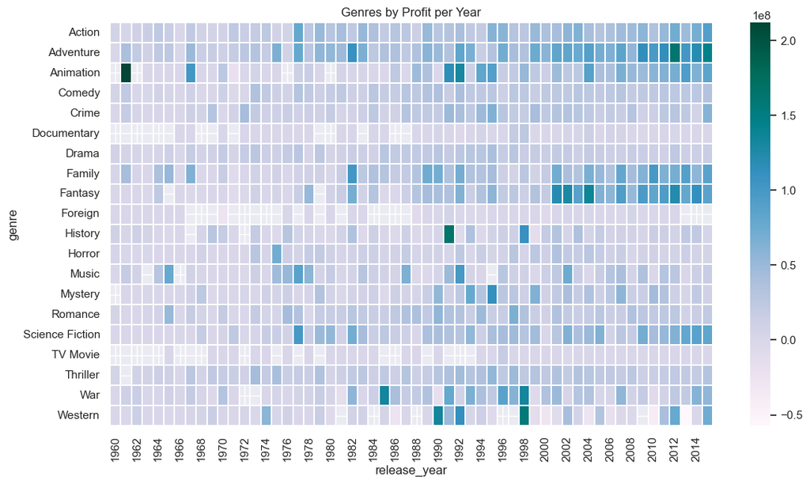

```python
sns.set(rc = {'figure.figsize' : (13,7)})
sns.heatmap(pivot_genre, cmap = 'PuBuGn', linewidths = .2)
plt.title('Genres by Profit per Year')
```

**The analysis of profit per genre per year shows how profitability trends vary widely across both genres and time. Some genres, like Adventure, Fantasy, and Animation, display consistently strong profits across multiple decades, while others such as Documentary, TV Movie, and Foreign remain comparatively weak or inconsistent. A heatmap was used to visualize these results, making it easy to identify periods of peak profitability as well as fluctuations in performance over time.**

### 6. Movies released in certain years achieve higher revenue/ROI than others

```python
movies_genre.head()
```

|  | popularity | budget | revenue | original_title | runtime | release_year | vote_count | vote_average | profit | genre | roi |
| --- | --- | --- | --- | --- | --- | --- | --- | --- | --- | --- | --- |
| 0 | 32.985763 | 150000000 | 1513528810 | Jurassic World | 124 | 2015 | 5562 | 6.500000 | 1363528810 | Action | 9.090192 |
| 0 | 32.985763 | 150000000 | 1513528810 | Jurassic World | 124 | 2015 | 5562 | 6.500000 | 1363528810 | Adventure | 9.090192 |
| 0 | 32.985763 | 150000000 | 1513528810 | Jurassic World | 124 | 2015 | 5562 | 6.500000 | 1363528810 | Science Fiction | 9.090192 |
| 0 | 32.985763 | 150000000 | 1513528810 | Jurassic World | 124 | 2015 | 5562 | 6.500000 | 1363528810 | Thriller | 9.090192 |
| 1 | 28.419936 | 150000000 | 378436354 | Mad Max: Fury Road | 120 | 2015 | 6185 | 7.100000 | 228436354 | Action | 1.522909 |

```python
# Using average per year to reduce the effect of volume changes

year_avgs = (
    movies_genre.loc[np.isfinite(movies_genre['roi'])]
     .groupby('release_year')[['revenue','roi']]
     .mean()
     .dropna()
     .reset_index()
     .rename(columns={'release_year':'year'})
)
```

```python
year_avgs.head()
```

|  | year | revenue | roi |
| --- | --- | --- | --- |
| 0 | 1960 | 15829791.666667 | 6.127400 |
| 1 | 1961 | 40055795.800000 | 8.848848 |
| 2 | 1962 | 19961705.485714 | 5.181289 |
| 3 | 1963 | 15149947.885714 | 2.608494 |
| 4 | 1964 | 39796993.862069 | 7.035513 |

```python
# Trend strength (non-parametric)

spearman_revenue = year_avgs[['year','revenue']].corr(method='spearman').iloc[0,1]
spearman_roi = year_avgs[['year','roi']].corr(method='spearman').iloc[0,1]

print(f"Spearman(year vs avg revenue) = {spearman_revenue:.3f}")
print(f"Spearman(year vs avg ROI)     = {spearman_roi:.3f}")
```

```
Spearman(year vs avg revenue) = 0.910
Spearman(year vs avg ROI)     = -0.446
```

```python
# Top 5 years by avg revenue and avg ROI

top5_rev_years = year_avgs.nlargest(5, 'revenue')[['year','revenue']]
top5_roi_years = year_avgs.nlargest(5, 'roi')[['year','roi']]

display(top5_rev_years)
display(top5_roi_years)
```

|  | year | revenue |
| --- | --- | --- |
| 55 | 2015 | 154679453.148077 |
| 54 | 2014 | 134690522.286252 |
| 52 | 2012 | 124013528.616056 |
| 53 | 2013 | 112221979.003205 |
| 41 | 2001 | 106517145.637975 |

|  | year | roi |
| --- | --- | --- |
| 26 | 1986 | 33074.737704 |
| 25 | 1985 | 1162.371159 |
| 51 | 2011 | 120.688962 |
| 39 | 1999 | 52.301377 |
| 17 | 1977 | 49.531412 |

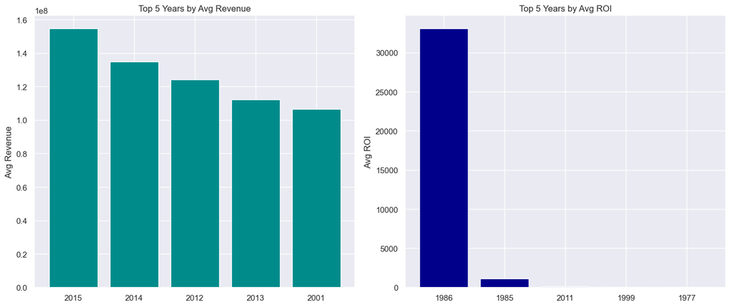

```python
fig, axes = plt.subplots(1,2, figsize=(14,6))

# Top 5 revenue years
axes[0].bar(top5_rev_years['year'].astype(str), top5_rev_years['revenue'], color='darkcyan')
axes[0].set_title('Top 5 Years by Avg Revenue')
axes[0].set_ylabel('Avg Revenue')

# Top 5 ROI years
axes[1].bar(top5_roi_years['year'].astype(str), top5_roi_years['roi'], color='darkblue')
axes[1].set_title('Top 5 Years by Avg ROI')
axes[1].set_ylabel('Avg ROI')

plt.tight_layout(); plt.show()
```

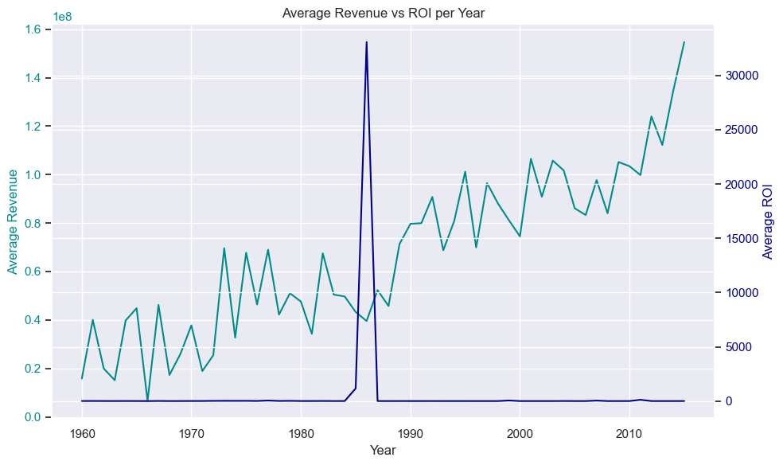

```python
fig, ax1 = plt.subplots(figsize=(10,6))

ax1.plot(year_avgs['year'], year_avgs['revenue'], color='darkcyan', label='Revenue')
ax1.set_xlabel('Year'); ax1.set_ylabel('Average Revenue', color='darkcyan')
ax1.tick_params(axis='y', labelcolor='darkcyan')

ax2 = ax1.twinx()
ax2.plot(year_avgs['year'], year_avgs['roi'], color='darkblue', label='ROI')
ax2.set_ylabel('Average ROI', color='darkblue')
ax2.tick_params(axis='y', labelcolor='darkblue')

plt.title('Average Revenue vs ROI per Year')
fig.tight_layout(); plt.show()
```

### 7. Genres with consistently high ROI are better long-term targets than high-budget genres

```python
movies_genre.head()
```

|  | popularity | budget | revenue | original_title | runtime | release_year | vote_count | vote_average | profit | genre | roi |
| --- | --- | --- | --- | --- | --- | --- | --- | --- | --- | --- | --- |
| 0 | 32.985763 | 150000000 | 1513528810 | Jurassic World | 124 | 2015 | 5562 | 6.500000 | 1363528810 | Action | 9.090192 |
| 0 | 32.985763 | 150000000 | 1513528810 | Jurassic World | 124 | 2015 | 5562 | 6.500000 | 1363528810 | Adventure | 9.090192 |
| 0 | 32.985763 | 150000000 | 1513528810 | Jurassic World | 124 | 2015 | 5562 | 6.500000 | 1363528810 | Science Fiction | 9.090192 |
| 0 | 32.985763 | 150000000 | 1513528810 | Jurassic World | 124 | 2015 | 5562 | 6.500000 | 1363528810 | Thriller | 9.090192 |
| 1 | 28.419936 | 150000000 | 378436354 | Mad Max: Fury Road | 120 | 2015 | 6185 | 7.100000 | 228436354 | Action | 1.522909 |

```python
# Average budget vs average ROI by genre

genre_budget = movies_genre.groupby('genre')['budget'].mean().rename('avg_budget')
genre_roi    = movies_genre.groupby('genre')['roi'].mean().rename('avg_roi')
budget_roi   = pd.concat([genre_budget, genre_roi], axis=1).dropna()
```

```python
budget_roi.head(5)
```

| genre | avg_budget | avg_roi |
| --- | --- | --- |
| Action | 27727820.331376 | 714.999015 |
| Adventure | 37543694.530931 | 1126.819397 |
| Animation | 23159781.606581 | 2.268490 |
| Comedy | 13297915.618244 | 52.962398 |
| Crime | 17663801.124815 | 1.752887 |

```python
# Rank correlation: are high budgets the same as high ROI?

kendall_tau = budget_roi['avg_budget'].rank().corr(budget_roi['avg_roi'].rank(), method='kendall')
print(f"[H6] Kendall tau(rank budget vs rank ROI) = {kendall_tau:.3f}")
```

```
[H6] Kendall tau(rank budget vs rank ROI) = 0.168
```

```python
# “Efficient” genres: above-median ROI at or below median budget

b_med   = budget_roi['avg_budget'].median()
roi_med = budget_roi['avg_roi'].median()
efficient_genres = (
    budget_roi[(budget_roi['avg_roi'] >= roi_med) & (budget_roi['avg_budget'] <= b_med)]
    .sort_values('avg_roi', ascending=False)
    .reset_index()
)
display(efficient_genres)
```

|  | genre | avg_budget | avg_roi |
| --- | --- | --- | --- |
| 0 | Romance | 12531271.847547 | 1218.318745 |
| 1 | Drama | 11880717.773529 | 479.537545 |
| 2 | Mystery | 16119270.062963 | 53.486201 |
| 3 | Comedy | 13297915.618244 | 52.962398 |
| 4 | Thriller | 17207693.769178 | 38.658836 |
| 5 | Horror | 6226529.210751 | 35.107782 |
| 6 | Documentary | 577149.148077 | 10.820285 |

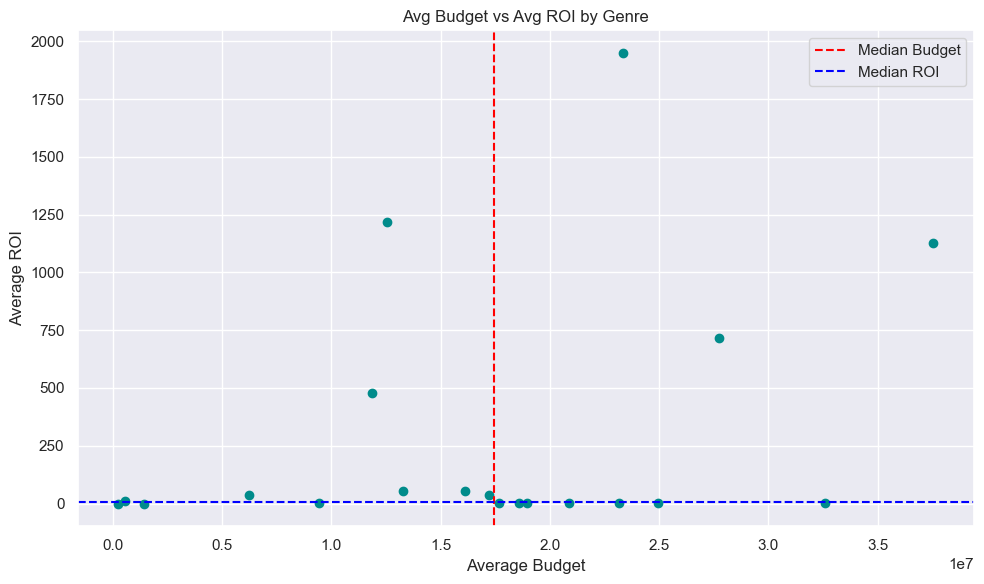

```python
plt.figure(figsize=(10,6))
plt.scatter(budget_roi['avg_budget'], budget_roi['avg_roi'], color='darkcyan')

plt.axvline(b_med, color='red', linestyle='--', label='Median Budget')
plt.axhline(roi_med, color='blue', linestyle='--', label='Median ROI')

plt.title('Avg Budget vs Avg ROI by Genre')
plt.xlabel('Average Budget')
plt.ylabel('Average ROI')
plt.legend()
plt.tight_layout()
plt.show()
```

**The analysis shows that genres such as Romance and Drama achieve exceptionally high ROI despite having only moderate budgets, while others like Horror and Documentary also perform efficiently at lower costs. The scatter plot of average budget versus average ROI highlights this pattern, with efficient genres appearing in the quadrant of low budget and high ROI, making them better long-term investment targets than high-budget categories.**